# Демонстрация обучения (fine-tuning) и классификации на основе BERT

```python
from transformers import BertConfig, BertForSequenceClassification, BertTokenizer, Trainer, TrainingArguments
from sklearn.model_selection import train_test_split
from sklearn.metrics import confusion_matrix, classification_report, accuracy_score, precision_recall_fscore_support
import torch
from datasets import Dataset
from torch.nn.functional import softmax
import pandas as pd
import seaborn as sns
import numpy as np
import random
import matplotlib.pyplot as plt
from time import time
import sys
from subprocess import call
```

## Содержание

1. Работа с CUDA  
2. Загрузка текстовых корпусов  
3. Токенизация  
4. Определение размера входа  
5. Подготовка наборов данных для BERT  
6. Подготовка модели BERT  
7. Обучение и тестирование BERT  
8. Классификация произвольного текста

### 1. Работа с CUDA

Для использования видеокарты необходимо установить CUDA и CUDNN.

Выведем характеристики видеокарты и CUDA:

```python
!nvidia-smi
```

```
Mon Nov  6 22:31:01 2023
+-----------------------------------------------------------------------------+
| NVIDIA-SMI 527.41       Driver Version: 527.41       CUDA Version: 12.0     |
|-------------------------------+----------------------+----------------------+
| GPU  Name            TCC/WDDM | Bus-Id        Disp.A | Volatile Uncorr. ECC |
| Fan  Temp  Perf  Pwr:Usage/Cap|         Memory-Usage | GPU-Util  Compute M. |
|                               |                      |               MIG M. |
|===============================+======================+======================|
|   0  NVIDIA GeForce ... WDDM  | 00000000:01:00.0 Off |                  N/A |
| N/A   35C    P0    24W /  N/A |      0MiB /  6144MiB |      0%      Default |
|                               |                      |                  N/A |
+-------------------------------+----------------------+----------------------+

+-----------------------------------------------------------------------------+
| Processes:                                                                  |
|  GPU   GI   CI        PID   Type   Process name                  GPU Memory |
|        ID   ID                                                   Usage      |
|=============================================================================|
|  No running processes found                                                 |
+-----------------------------------------------------------------------------+
```

```python
print('Python VERSION:', sys.version)
print('\npyTorch VERSION:', torch.__version__)
print('\nCUDA VERSION:')
! nvcc --version
print('\nCUDNN VERSION:', torch.backends.cudnn.version())
print('\nNumber CUDA Devices:', torch.cuda.device_count())
print('Current cuda device:', torch.cuda.current_device())
print('Cuda device name: ', torch.cuda.get_device_name(0))
```

```
Python VERSION: 3.9.12 (main, Apr  4 2022, 05:22:27) [MSC v.1916 64 bit (AMD64)]

pyTorch VERSION: 2.0.1+cu118

CUDA VERSION:
nvcc: NVIDIA (R) Cuda compiler driver
Copyright (c) 2005-2022 NVIDIA Corporation
Built on Mon_Oct_24_19:40:05_Pacific_Daylight_Time_2022
Cuda compilation tools, release 12.0, V12.0.76
Build cuda_12.0.r12.0/compiler.31968024_0

CUDNN VERSION: 8700

Number CUDA Devices: 1
Current cuda device: 0
Cuda device name:  NVIDIA GeForce RTX 3060 Laptop GPU
```

```python
# Определяем GPU или CPU
device = torch.device("cuda:0" if torch.cuda.is_available() else "cpu")
device
```

```
device(type='cuda', index=0)
```

Полезные ссылки по использованию GPU в PyTorch:

- [PyTorch: Switching to the GPU](https://towardsdatascience.com/pytorch-switching-to-the-gpu-a7c0b21e8a99)
- [Use GPU in your PyTorch code](https://medium.com/ai%C2%B3-theory-practice-business/use-gpu-in-your-pytorch-code-676a67faed09)

### 2. Загрузка текстовых корпусов

Классы (метки, labels) для BERT должны быть в диапазоне `[0, 1, ..., num_classes-1]`.

```python
# Соответствие числовых меток (индексов в данном списке) классам тональности:
# 'neutral': 0, 'positive': 1, 'negative': 2
class_names = ['neutral', 'positive', 'negative']
```

```python
# Корпус цитат из новостей с семинара РОМИП-2012, размеченных по трем классам тональности:
# негатив -1, нейтрально 0, позитив +1
df_train_init = pd.read_csv("romip2012_news_train.csv", sep='\t', header=0)
```

```python
df_train_init.head()
```

|  | id | score | text |
| --- | --- | --- | --- |
| 0 | 0 | 0 | Далее в своей проповеди он напомнил, что по би... |
| 1 | 1 | -1 | Меня отпустили. У Коли @nlyaskin забирают вещи... |
| 2 | 3 | 0 | В интервью РИА Новости уполномоченный по права... |
| 3 | 7 | 0 | Бывший главный тренер сборной Англии Грэм Тэйл... |
| 4 | 8 | -1 | На телах жертв были обнаружены многочисленные ... |

```python
def making_label(st, class_names):
    '''Функция преобразует метку элемента DataFrame из множества {-1, 0, +1} в соответствии со списком class_names'''

    neutral = class_names.index('neutral')
    positive = class_names.index('positive')
    negative = class_names.index('negative')

    if st == 1:
        return positive
    elif st == 0:
        return neutral
    elif st == -1:
        return negative
    else:
        print('Error!')
```

```python
# Заменяем метки
df_train_init['score'] = df_train_init['score'].apply(making_label, args=(class_names,))
```

```python
# Чтобы использовать класс Trainer, переименовываем 'score' в 'label'
df_train_init = df_train_init.rename(columns={'score': 'label'})
```

```python
df_train_init.head()
```

|  | id | label | text |
| --- | --- | --- | --- |
| 0 | 0 | 0 | Далее в своей проповеди он напомнил, что по би... |
| 1 | 1 | 2 | Меня отпустили. У Коли @nlyaskin забирают вещи... |
| 2 | 3 | 0 | В интервью РИА Новости уполномоченный по права... |
| 3 | 7 | 0 | Бывший главный тренер сборной Англии Грэм Тэйл... |
| 4 | 8 | 2 | На телах жертв были обнаружены многочисленные ... |

```
2    1864
1    1115
0     914
Name: label, dtype: int64
```

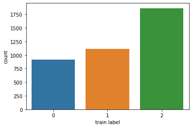

```python
# Выводим распределение по классам
print(df_train_init.label.value_counts())
sns.countplot(x=df_train_init.label)
plt.xlabel('train label');
```

```python
df_test = pd.read_csv("romip2012_news_test.csv", sep='\t', header=0)
```

```python
df_test.head()
```

|  | id | score | text |
| --- | --- | --- | --- |
| 0 | 1001 | 0 | Джазбэнд под руководством Пеппе Сервилло, кото... |
| 1 | 1003 | -1 | Посредством этих структур десяткам тысяч избир... |
| 2 | 1004 | -1 | Появилось очень много бедных избирателей. В се... |
| 3 | 1005 | -1 | За теленовостями - главным источником информац... |
| 4 | 1006 | -1 | Такого раньше никогда не было, чтобы местные ч... |

```python
df_test['score'] = df_test['score'].apply(making_label, args=(class_names,))
```

```python
df_test = df_test.rename(columns={'score': 'label'})
```

```python
df_test.head()
```

|  | id | label | text |
| --- | --- | --- | --- |
| 0 | 1001 | 0 | Джазбэнд под руководством Пеппе Сервилло, кото... |
| 1 | 1003 | 2 | Посредством этих структур десяткам тысяч избир... |
| 2 | 1004 | 2 | Появилось очень много бедных избирателей. В се... |
| 3 | 1005 | 2 | За теленовостями - главным источником информац... |
| 4 | 1006 | 2 | Такого раньше никогда не было, чтобы местные ч... |

```
2    1890
1    1448
0    1235
Name: label, dtype: int64
```

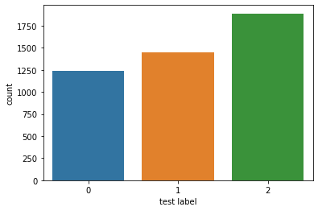

```python
print(df_test.label.value_counts())
sns.countplot(x=df_test.label)
plt.xlabel('test label');
```

### 3. Токенизация

Токенизатор и его словарь связаны с используемой моделью.

В этом ноутбуке применяется модель ruBert-base, предобученная на русскоязычных корпусах.

В качестве альтернативы можно использовать модель rubert-base-cased-sentiment, предобученную на русскоязычных корпусах с разметкой по тональности.

```python
PRE_TRAINED_MODEL_NAME = 'ai-forever/ruBert-base'
#PRE_TRAINED_MODEL_NAME = 'blanchefort/rubert-base-cased-sentiment'
```

```python
tokenizer = BertTokenizer.from_pretrained(PRE_TRAINED_MODEL_NAME)
tokenizer
```

```
BertTokenizer(name_or_path='ai-forever/ruBert-base', vocab_size=120138, model_max_length=1000000000000000019884624838656, is_fast=False, padding_side='right', truncation_side='right', special_tokens={'unk_token': '[UNK]', 'sep_token': '[SEP]', 'pad_token': '[PAD]', 'cls_token': '[CLS]', 'mask_token'…
```

*Загруженные для модели файлы находятся здесь:* `C:\Users\<User_name>\\.cache\huggingface\transformers`

Вариант для токенизации – использовать BertTokenizerFast.

```python
# Проверяем, приводит ли токенизатор текст к нижнему регистру.
# Это поведение можно изменить при помощи параметра do_lower_case при загрузке токенизатора или установкой этого значения:
tokenizer.init_kwargs['do_lower_case']
```

```
True
```

```python
print(f'Размер словаря: {len(tokenizer.vocab)}')
```

```
Размер словаря: 120138
```

```python
# Выводим фрагмент словаря
list(tokenizer.vocab.keys())[10000:10020]
```

```
['Ещё',
 'магазин',
 'журналист',
 '##восто',
 'перехва',
 'атом',
 'золото',
 '##лес',
 'продемонстри',
 'поу',
 'мясо',
 'привык',
 'станут',
 'желания',
 'принимал',
 '##вики',
 'Эли',
 'дисципли',
 '##жке',
 'фабри']
```

```python
# Специальные токены и их id
print(tokenizer.pad_token, tokenizer.pad_token_id)
print(tokenizer.unk_token, tokenizer.unk_token_id)
print(tokenizer.cls_token, tokenizer.cls_token_id)
print(tokenizer.sep_token, tokenizer.sep_token_id)
print(tokenizer.mask_token, tokenizer.mask_token_id)
```

```
[PAD] 0
[UNK] 100
[CLS] 101
[SEP] 102
[MASK] 103
```

```python
# Пример токенизации
#text = df_train_init.iloc[0].text
text = 'Давайте как-нибудь встретимся в кафе "Моё место"!'
print(f'text: {text}')

tokens = tokenizer.tokenize(text)
print(f'\ntokens: {tokens}')

token_ids = tokenizer.convert_tokens_to_ids(tokens)
print(f'\ntoken_ids: {token_ids}')
```

```
text: Давайте как-нибудь встретимся в кафе "Моё место"!

tokens: ['дав', '##а', '##ите', 'как', '-', 'нибудь', 'встретимся', 'в', 'кафе', '"', 'мое', 'место', '"', '!']

token_ids: [3823, 377, 42699, 785, 133, 2103, 42531, 113, 5558, 152, 5515, 1613, 152, 177]
```

Для токенизации используется вызов функции [PreTrainedTokenizerBase.**call**()](https://huggingface.co/docs/transformers/internal/tokenization_utils#transformers.PreTrainedTokenizerBase.__call__):

```python
encoding = tokenizer(
  text,
  max_length=40,
  add_special_tokens=True,     # Add '[CLS]'
  padding='max_length',        # 'longest', 'max_length', 'do_not_pad'
  truncation='longest_first',
  return_token_type_ids=True,
  return_attention_mask=True,
  return_special_tokens_mask=True
)

for key, value in encoding.items():
    print(f'"{key}": {value}\n')
```

```
"input_ids": [101, 3823, 377, 42699, 785, 133, 2103, 42531, 113, 5558, 152, 5515, 1613, 152, 177, 102, 0, 0, 0, 0, 0, 0, 0, 0, 0, 0, 0, 0, 0, 0, 0, 0, 0, 0, 0, 0, 0, 0, 0, 0]

"token_type_ids": [0, 0, 0, 0, 0, 0, 0, 0, 0, 0, 0, 0, 0, 0, 0, 0, 0, 0, 0, 0, 0, 0, 0, 0, 0, 0, 0, 0, 0, 0, 0, 0, 0, 0, 0, 0, 0, 0, 0, 0]

"special_tokens_mask": [1, 0, 0, 0, 0, 0, 0, 0, 0, 0, 0, 0, 0, 0, 0, 1, 1, 1, 1, 1, 1, 1, 1, 1, 1, 1, 1, 1, 1, 1, 1, 1, 1, 1, 1, 1, 1, 1, 1, 1]

"attention_mask": [1, 1, 1, 1, 1, 1, 1, 1, 1, 1, 1, 1, 1, 1, 1, 1, 0, 0, 0, 0, 0, 0, 0, 0, 0, 0, 0, 0, 0, 0, 0, 0, 0, 0, 0, 0, 0, 0, 0, 0]
```

```python
len(encoding['input_ids'])
```

```
40
```

```python
# Преобразуем id обратно в токены
print(tokenizer.convert_ids_to_tokens(encoding['input_ids']))
```

```
['[CLS]', 'дав', '##а', '##ите', 'как', '-', 'нибудь', 'встретимся', 'в', 'кафе', '"', 'мое', 'место', '"', '!', '[SEP]', '[PAD]', '[PAD]', '[PAD]', '[PAD]', '[PAD]', '[PAD]', '[PAD]', '[PAD]', '[PAD]', '[PAD]', '[PAD]', '[PAD]', '[PAD]', '[PAD]', '[PAD]', '[PAD]', '[PAD]', '[PAD]', '[PAD]', '[PAD]'…
```

```python
# Преобразуем id токенов в текст
print(tokenizer.decode(encoding['input_ids']))
```

```
[CLS] даваите как - нибудь встретимся в кафе " мое место "! [SEP] [PAD] [PAD] [PAD] [PAD] [PAD] [PAD] [PAD] [PAD] [PAD] [PAD] [PAD] [PAD] [PAD] [PAD] [PAD] [PAD] [PAD] [PAD] [PAD] [PAD] [PAD] [PAD] [PAD] [PAD]
```

### 4. Определение размера входа

Модели BERT требуют фиксированного размера входа (максимум – 512 токенов).  
Для определения размера входа проанализируем текстовый корпус.

```python
def get_token_len(df, tokenizer):
    '''Функция для входного Dataframe возвращает список размеров текстов в токенах'''
    token_lens = []
    for txt in df.text:
        tokens = tokenizer.encode(txt)
        token_lens.append(len(tokens))
    return token_lens
```

```
min length = 15 tokens
max length = 984 tokens
```

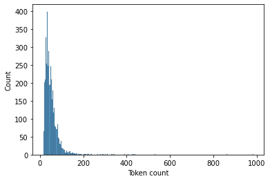

```python
token_lens_train = get_token_len(df_train_init, tokenizer)
print(f'min length = {min(token_lens_train)} tokens')
print(f'max length = {max(token_lens_train)} tokens')
sns.histplot(token_lens_train)
#plt.xlim([0, 256]);   # Сжать график
plt.xlabel('Token count');
```

Установим максимальную длину:

```python
MAX_LEN = 200   # MAX_LEN = 512
```

Найдем количество текстов и долю, размер которых больше максимального:

```python
outliers_number_train = sum(len > MAX_LEN for len in token_lens_train)
print(f'{outliers_number_train} from {len(df_train_init)}')
print(outliers_number_train / len(df_train_init))
```

```
27 from 3893
0.006935525301823786
```

```
min length = 15 tokens
max length = 475 tokens
```

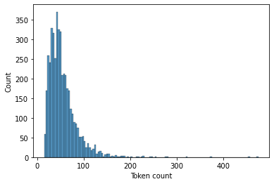

```python
token_lens_test = get_token_len(df_test, tokenizer)
print(f'min length = {min(token_lens_test)} tokens')
print(f'max length = {max(token_lens_test)} tokens')
sns.histplot(token_lens_test)
#plt.xlim([0, 256]);   # Сжать график
plt.xlabel('Token count');
```

```python
outliers_number_test = sum(len > MAX_LEN for len in token_lens_test)
print(f'{outliers_number_test} from {len(df_test)}')
print(outliers_number_test / len(df_test))
```

```
19 from 4573
0.0041548217800131204
```

В качестве размера входа берем `MAX_LEN`.

### 5. Подготовка наборов данных для BERT

Для воспроизводимости результатов инициализируем генераторы случайных чисел Python, Numpy и PyTorch:

```python
seed = 42
random.seed(seed)
np.random.seed(seed)
torch.manual_seed(seed)
```

```
<torch._C.Generator at 0x228933ee3d0>
```

*Замечание*. Полная воспроизводимость результатов таким способом не гарантируется: https://pytorch.org/docs/stable/notes/randomness.html.

```python
# Делим обучающий корпус на обучающую (training) часть и проверочную (validation, evaluation) часть
df_train, df_eval = train_test_split(df_train_init, test_size=0.1, random_state=seed)
print(f'train:\n{df_train.head()}')
print(f'\neval:\n{df_eval.head()}')
```

```
train:
        id  label                                               text
1490  1887      2  По мнению выступавших, если нашим заводам нужн...
358    500      2  Кроме того, по мнению эксперта, президенту Бел...
2752  3332      2  В связи с изменениями в действующем законодате...
299    418      1  Молодые люди должны понимать, что служба в арм...
1003  1293      1  Это чувство живет у меня до сих пор. Каждый ра...

eval:
         id  label                                               text
3546  10373      1  В документе четко указано, что украинской стор...
2398   2929      0  4 апреля вице-премьер Игорь Сечин заявил, что ...
3865  10955      2  Если бы мы не сумели дать на него ответ, то не...
1187   1520      2  Это только слова Лукашенко. Вот когда выпустят...
315     439      0  Результаты подсчета голосов будут проходить по...
```

```python
print('train init dataset shape:', df_train_init.shape)
print('train dataset shape:', df_train.shape)
print('evaluation dataset shape:', df_eval.shape)
print('test dataset shape:', df_test.shape)
```

```
train init dataset shape: (3893, 3)
train dataset shape: (3503, 3)
evaluation dataset shape: (390, 3)
test dataset shape: (4573, 3)
```

Формируем объекты класса `Dataset`, необходимые для моделей `transformers` (https://huggingface.co/docs/datasets/):

```python
train_init_dataset = Dataset.from_pandas(df_train_init)
train_dataset = Dataset.from_pandas(df_train)
eval_dataset = Dataset.from_pandas(df_eval)
test_dataset = Dataset.from_pandas(df_test)

print(f'train_dataset:\n\n{train_dataset}')
```

```
train_dataset:

Dataset({
    features: ['id', 'label', 'text', '__index_level_0__'],
    num_rows: 3503
})
```

```python
train_dataset[0]
```

```
{'id': 1887,
 'label': 2,
 'text': 'По мнению выступавших, если нашим заводам нужны технологи машиностроения или другие специалисты, то они могли бы взять на себя часть финансовых затрат на их обучение.',
 '__index_level_0__': 1490}
```

```python
def tokenize(batch):
    '''Функция для токенизации Dataset'''
    return tokenizer(
        batch['text'],
        max_length=MAX_LEN,
        padding='max_length',        # 'longest', 'max_length', 'do_not_pad'
        truncation='longest_first'
    )
```

Осуществляем токенизацию датасетов:

```python
train_init_dataset = train_init_dataset.map(tokenize, batched=True, batch_size=len(train_init_dataset))
train_dataset = train_dataset.map(tokenize, batched=True, batch_size=len(train_dataset))
eval_dataset = eval_dataset.map(tokenize, batched=True, batch_size=len(eval_dataset))
test_dataset = test_dataset.map(tokenize, batched=True, batch_size=len(test_dataset))
```

```python
# Определяем, что будет возвращать функция __getitem__() для Dataset
train_init_dataset.set_format('torch', columns=['input_ids', 'attention_mask', 'label'])
train_dataset.set_format('torch', columns=['input_ids', 'attention_mask', 'label'])
eval_dataset.set_format('torch', columns=['input_ids', 'attention_mask', 'label'])
test_dataset.set_format('torch', columns=['input_ids', 'attention_mask', 'label'])
```

```python
train_dataset
```

```
Dataset({
    features: ['id', 'label', 'text', '__index_level_0__', 'input_ids', 'token_type_ids', 'attention_mask'],
    num_rows: 3503
})
```

```python
# Вызов должен возвращать только те поля, которые были указаны в train_dataset.set_format():
train_dataset[0]
```

```
{'label': tensor(2),
 'input_ids': tensor([  101,   654,  3318, 97695,   121,  1081,  8120,  7563,   386,  6474,
          3628, 40155,   967,  2455,  8971,   121,   696,   991,  3029,   707,
          4889,   660,  1231,  2134, 12215, 23002,   660,   972, 12847,   126,
           102,     0,     0,     0,     0,     0,     0,     0,     0,     0,
             0,     0,     0,     0,     0,     0,     0,     0,     0,     0,
             0,     0,     0,     0,     0,     0,     0,     0,     0,     0,
             0,     0,     0,     0,     0,     0,     0,     0,     0,     0,
             0,     0,     0,     0,     0,     0,     0,     0,     0,     0,
             0,     0,     0,     0,     0,     0,     0,     0,     0,     0,
             0,     0,     0,     0,     0,     0,     0,     0,     0,     0,
             0,     0,     0,     0,     0,     0,     0,     0,     0,     0,
             0,     0,     0,     0,     0,     0,     0,     0,     0,     0,
             0,     0,     0,     0,     0,     0,     0,     0,     0,     0,
             0,     0,     0,     0,     0,     0,     0,     0,     0,     0,
             0,     0,     0,     0,     0,     0,     0,     0,     0,     0,
             0,     0,     0,     0,     0,     0,     0,     0,     0,     0,
             0,     0,     0,     0,     0,     0,     0,     0,     0,     0,
             0,     0,     0,     0,     0,     0,     0,     0,     0,     0,
             0,     0,     0,     0,     0,     0,     0,     0,     0,     0,
             0,     0,     0,     0,     0,     0,     0,     0,     0,     0]),
 'attention_mask': tensor([1, 1, 1, 1, 1, 1, 1, 1, 1, 1, 1, 1, 1, 1, 1, 1, 1, 1, 1, 1, 1, 1, 1, 1,
         1, 1, 1, 1, 1, 1, 1, 0, 0, 0, 0, 0, 0, 0, 0, 0, 0, 0, 0, 0, 0, 0, 0, 0,
         0, 0, 0, 0, 0, 0, 0, 0, 0, 0, 0, 0, 0, 0, 0, 0, 0, 0, 0, 0, 0, 0, 0, 0,
         0, 0, 0, 0, 0, 0, 0, 0, 0, 0, 0, 0, 0, 0, 0, 0, 0, 0, 0, 0, 0, 0, 0, 0,
         0, 0, 0, 0, 0, 0, 0, 0, 0, 0, 0, 0, 0, 0, 0, 0, 0, 0, 0, 0, 0, 0, 0, 0,
         0, 0, 0, 0, 0, 0, 0, 0, 0, 0, 0, 0, 0, 0, 0, 0, 0, 0, 0, 0, 0, 0, 0, 0,
         0, 0, 0, 0, 0, 0, 0, 0, 0, 0, 0, 0, 0, 0, 0, 0, 0, 0, 0, 0, 0, 0, 0, 0,
         0, 0, 0, 0, 0, 0, 0, 0, 0, 0, 0, 0, 0, 0, 0, 0, 0, 0, 0, 0, 0, 0, 0, 0,
         0, 0, 0, 0, 0, 0, 0, 0])}
```

### 6. Подготовка модели BERT

Библиотека `transformers` поддерживает несколько вариантов обучения (*fine tuning*) и тестирования.  
В данном ноутбуке используется класс [Trainer](https://huggingface.co/docs/transformers/training#trainer) ([документация](https://huggingface.co/transformers/main_classes/trainer.html)).

```python
# Загружаем предобученную модель
# model = BertForSequenceClassification.from_pretrained(PRE_TRAINED_MODEL_NAME)
# model = BertForSequenceClassification.from_pretrained(PRE_TRAINED_MODEL_NAME, from_tf=True) # Используем веса в формате TensorFlow
```

```python
# Загружаем конфигурацию
config = BertConfig.from_pretrained(PRE_TRAINED_MODEL_NAME)
config
```

```
BertConfig {
  "architectures": [
    "BertForMaskedLM"
  ],
  "attention_probs_dropout_prob": 0.1,
  "classifier_dropout": null,
  "directionality": "bidi",
  "hidden_act": "gelu",
  "hidden_dropout_prob": 0.1,
  "hidden_size": 768,
  "initializer_range": 0.02,
  "intermediate_size": 3072,
  "layer_norm_eps": 1e-12,
  "max_position_embeddings": 512,
  "model_type": "bert",
  "num_attention_heads": 12,
  "num_hidden_layers": 12,
  "pad_token_id": 0,
  "pooler_fc_size": 768,
  "pooler_num_attention_heads": 12,
  "pooler_num_fc_layers": 3,
  "pooler_size_per_head": 128,
  "pooler_type": "first_token_transform",
  "position_embedding_type": "absolute",
  "transformers_version": "4.29.2",
  "type_vocab_size": 2,
  "use_cache": true,
  "vocab_size": 120138
}
```

```python
config.num_labels
```

```
2
```

```python
config.num_labels = 3
```

```python
# Загружаем предобученную модель
model = BertForSequenceClassification.from_pretrained(pretrained_model_name_or_path=PRE_TRAINED_MODEL_NAME, config=config)
```

[output not shown]

```python
model
```

```
BertForSequenceClassification(
  (bert): BertModel(
    (embeddings): BertEmbeddings(
      (word_embeddings): Embedding(120138, 768, padding_idx=0)
      (position_embeddings): Embedding(512, 768)
      (token_type_embeddings): Embedding(2, 768)
      (LayerNorm): LayerNorm((768,), eps=1e-12, elementwise_affine=True)
      (dropout): Dropout(p=0.1, inplace=False)
    )
    (encoder): BertEncoder(
      (layer): ModuleList(
        (0-11): 12 x BertLayer(
          (attention): BertAttention(
            (self): BertSelfAttention(
              (query): Linear(in_features=768, out_features=768, bias=True)
              (key): Linear(in_features=768, out_features=768, bias=True)
              (value): Linear(in_features=768, out_features=768, bias=True)
              (dropout): Dropout(p=0.1, inplace=False)
            )
            (output): BertSelfOutput(
              (dense): Linear(in_features=768, out_features=768, bias=True)
              (LayerNorm): LayerNorm((768,), eps=1e-12, elementwise_affine=True)
              (dropout): Dropout(p=0.1, inplace=False)
            )
          )
          (intermediate): BertIntermediate(
            (dense): Linear(in_features=768, out_features=3072, bias=True)
            (intermediate_act_fn): GELUActivation()
          )
          (output): BertOutput(
            (dense): Linear(in_features=3072, out_features=768, bias=True)
            (LayerNorm): LayerNorm((768,), eps=1e-12, elementwise_affine=True)
            (dropout): Dropout(p=0.1, inplace=False)
          )
        )
      )
    )
    (pooler): BertPooler(
      (dense): Linear(in_features=768, out_features=768, bias=True)
      (activation): Tanh()
    )
  )
  (dropout): Dropout(p=0.1, inplace=False)
  (classifier): Linear(in_features=768, out_features=3, bias=True)
)
```

```python
# Выводим конфигурацию модели
model.config
```

```
BertConfig {
  "_name_or_path": "ai-forever/ruBert-base",
  "architectures": [
    "BertForMaskedLM"
  ],
  "attention_probs_dropout_prob": 0.1,
  "classifier_dropout": null,
  "directionality": "bidi",
  "hidden_act": "gelu",
  "hidden_dropout_prob": 0.1,
  "hidden_size": 768,
  "id2label": {
    "0": "LABEL_0",
    "1": "LABEL_1",
    "2": "LABEL_2"
  },
  "initializer_range": 0.02,
  "intermediate_size": 3072,
  "label2id": {
    "LABEL_0": 0,
    "LABEL_1": 1,
    "LABEL_2": 2
  },
  "layer_norm_eps": 1e-12,
  "max_position_embeddings": 512,
  "model_type": "bert",
  "num_attention_heads": 12,
  "num_hidden_layers": 12,
  "pad_token_id": 0,
  "pooler_fc_size": 768,
  "pooler_num_attention_heads": 12,
  "pooler_num_fc_layers": 3,
  "pooler_size_per_head": 128,
  "pooler_type": "first_token_transform",
  "position_embedding_type": "absolute",
  "transformers_version": "4.29.2",
  "type_vocab_size": 2,
  "use_cache": true,
  "vocab_size": 120138
}
```

```python
model.config.num_labels
```

```
3
```

```python
# Выводим структуру модели и количество параметров
all_parameters = 0
trainable_parameters = 0
for parameter in model.named_parameters():
    print(f'{parameter[0]}: {list(parameter[1].data.size())} - {parameter[1].numel()}')
    all_parameters += parameter[1].numel()
    if parameter[1].requires_grad:
        trainable_parameters += parameter[1].numel()

print(f'\nAll parameters = {all_parameters}')
print(f'Trainable parameters = {trainable_parameters}')
```

```
bert.embeddings.word_embeddings.weight: [120138, 768] - 92265984
bert.embeddings.position_embeddings.weight: [512, 768] - 393216
bert.embeddings.token_type_embeddings.weight: [2, 768] - 1536
bert.embeddings.LayerNorm.weight: [768] - 768
bert.embeddings.LayerNorm.bias: [768] - 768
bert.encoder.layer.0.attention.self.query.weight: [768, 768] - 589824
bert.encoder.layer.0.attention.self.query.bias: [768] - 768
bert.encoder.layer.0.attention.self.key.weight: [768, 768] - 589824
bert.encoder.layer.0.attention.self.key.bias: [768] - 768
bert.encoder.layer.0.attention.self.value.weight: [768, 768] - 589824
bert.encoder.layer.0.attention.self.value.bias: [768] - 768
bert.encoder.layer.0.attention.output.dense.weight: [768, 768] - 589824
bert.encoder.layer.0.attention.output.dense.bias: [768] - 768
bert.encoder.layer.0.attention.output.LayerNorm.weight: [768] - 768
bert.encoder.layer.0.attention.output.LayerNorm.bias: [768] - 768
bert.encoder.layer.0.intermediate.dense.weight: [3072, 768] - 2359296
bert.encoder.layer.0.intermediate.dense.bias: [3072] - 3072
bert.encoder.layer.0.output.dense.weight: [768, 3072] - 2359296
bert.encoder.layer.0.output.dense.bias: [768] - 768
bert.encoder.layer.0.output.LayerNorm.weight: [768] - 768
bert.encoder.layer.0.output.LayerNorm.bias: [768] - 768
bert.encoder.layer.1.attention.self.query.weight: [768, 768] - 589824
bert.encoder.layer.1.attention.self.query.bias: [768] - 768
bert.encoder.layer.1.attention.self.key.weight: [768, 768] - 589824
bert.encoder.layer.1.attention.self.key.bias: [768] - 768
bert.encoder.layer.1.attention.self.value.weight: [768, 768] - 589824
bert.encoder.layer.1.attention.self.value.bias: [768] - 768
bert.encoder.layer.1.attention.output.dense.weight: [768, 768] - 589824
bert.encoder.layer.1.attention.output.dense.bias: [768] - 768
bert.encoder.layer.1.attention.output.LayerNorm.weight: [768] - 768
bert.encoder.layer.1.attention.output.LayerNorm.bias: [768] - 768
bert.encoder.layer.1.intermediate.dense.weight: [3072, 768] - 2359296
bert.encoder.layer.1.intermediate.dense.bias: [3072] - 3072
bert.encoder.layer.1.output.dense.weight: [768, 3072] - 2359296
bert.encoder.layer.1.output.dense.bias: [768] - 768
bert.encoder.layer.1.output.LayerNorm.weight: [768] - 768
bert.encoder.layer.1.output.LayerNorm.bias: [768] - 768
bert.encoder.layer.2.attention.self.query.weight: [768, 768] - 589824
bert.encoder.layer.2.attention.self.query.bias: [768] - 768
bert.encoder.layer.2.attention.self.key.weight: [768, 768] - 589824
```

[output cut: 149 more lines]

```
bert.encoder.layer.11.attention.output.LayerNorm.weight: [768] - 768
bert.encoder.layer.11.attention.output.LayerNorm.bias: [768] - 768
bert.encoder.layer.11.intermediate.dense.weight: [3072, 768] - 2359296
bert.encoder.layer.11.intermediate.dense.bias: [3072] - 3072
bert.encoder.layer.11.output.dense.weight: [768, 3072] - 2359296
bert.encoder.layer.11.output.dense.bias: [768] - 768
bert.encoder.layer.11.output.LayerNorm.weight: [768] - 768
bert.encoder.layer.11.output.LayerNorm.bias: [768] - 768
bert.pooler.dense.weight: [768, 768] - 589824
bert.pooler.dense.bias: [768] - 768
classifier.weight: [3, 768] - 2304
classifier.bias: [3] - 3

All parameters = 178309635
Trainable parameters = 178309635
```

```python
# Выводим веса первого слоя (должны быть одинаковыми после каждой загрузки одной и той же модели)
model.bert.embeddings.word_embeddings.weight
```

```
Parameter containing:
tensor([[-0.0279, -0.0080, -0.0127,  ...,  0.0099,  0.0004, -0.0009],
        [-0.0388,  0.0022,  0.0264,  ...,  0.0068,  0.0117, -0.0185],
        [-0.0589, -0.0092,  0.0043,  ...,  0.0090,  0.0010,  0.0158],
        ...,
        [-0.0403,  0.0152, -0.0609,  ..., -0.0260,  0.0587, -0.0274],
        [-0.0807,  0.0445,  0.0360,  ..., -0.0074, -0.0486, -0.0236],
        [-0.0532,  0.0153,  0.0033,  ..., -0.0458, -0.0397, -0.0135]],
       requires_grad=True)
```

```python
# Выводим веса последнего слоя - классификатора.
# Если в загруженной модели этих слоев не было, то они инициализируются случайным образом.
# Но при инициализации генератора случайных чисел одной и той же константой, они должны быть одинаковыми.
model.classifier.weight
```

```
Parameter containing:
tensor([[-0.0112, -0.0135, -0.0388,  ...,  0.0214, -0.0060,  0.0085],
        [ 0.0021, -0.0092,  0.0177,  ...,  0.0094,  0.0405,  0.0141],
        [-0.0031, -0.0258, -0.0120,  ...,  0.0223, -0.0148,  0.0065]],
       requires_grad=True)
```

```python
def compute_metrics(pred):
    '''Функция возвращает метрики качества'''
    labels = pred.label_ids
    preds = pred.predictions.argmax(-1)
    precision, recall, f1, _ = precision_recall_fscore_support(labels, preds)
    acc = accuracy_score(labels, preds)
    return {
        'accuracy': acc,
        'f1_mean': np.mean(f1),
        'f1': f1.tolist(),
        'precision': precision.tolist(),
        'recall': recall.tolist()
    }
```

```python
# Устанавливаем параметры обучения
training_args = TrainingArguments(
    output_dir='./results',          # выходной каталог
    overwrite_output_dir=True,       # перезаписывать контрольные точки
    save_steps=5000,                 # количество шагов до обновления контрольной точки
    num_train_epochs=10,             # количество эпох обучения
    per_device_train_batch_size=2,   # размер батча на устройство при обучении
    per_device_eval_batch_size=2,    # размер батча при оценке
    weight_decay=0.01,               # коэффициент регуляризации
    learning_rate=1e-5,              # скорость обучения
    logging_dir='./logs',            # каталог для логов
    evaluation_strategy='epoch'      # 'no', 'steps', 'epoch' (оценка в конце каждой эпохи)
)
```

```python
# Проверяем, что модель будет использовать GPU
training_args.device
```

```
device(type='cuda', index=0)
```

```python
# Проверяем, что модель изначально загрузилась на cpu
model.device
```

```
device(type='cpu')
```

```python
# Создаем объект класса Trainer
# В нем происходит перемещение модели на gpu и инициализация генератора случайных чисел
trainer = Trainer(
    model=model,
    args=training_args,
    compute_metrics=compute_metrics
)
```

```python
# Проверяем, что Trainer переместил модель на gpu
model.device
```

```
device(type='cuda', index=0)
```

### 7. Обучение и тестирование BERT

Сначала необходимо подобрать *гиперпараметры модели* – количество эпох обучения, скорость обучения, размер батча, коэффициент регуляризации и т.п. Гиперпараметры подбираются с использованием проверочного (валидационного) набора данных, который выделяется из обучающего (`eval_dataset`).  
В этом примере мы подберем только количество эпох – запустим обучение на 10 эпохах, а в конце посмотрим, как соотносятся ошибки на обучающих и валидационных данных.  
Финальную модель можно строить на основе всего набора обучающих данных с уже подбранными гиперпараметрами.

```python
# Для обучения и оценки в процессе обучения используем разные наборы данных
trainer.train_dataset = train_dataset
trainer.eval_dataset = eval_dataset
```

Обучаем модель (если возникает ошибка памяти CUDA, можно попробовать уменьшить размер батча):

```python
start_time = time()

trainer.train()

print(f'Time: {time() - start_time:.1f} sec')
```

[17520/17520 46:11, Epoch 10/10]

| Epoch | Training Loss | Validation Loss | Accuracy | F1 Mean | F1 | Precision | Recall |
| --- | --- | --- | --- | --- | --- | --- | --- |
| 1 | 0.796600 | 0.811619 | 0.807692 | 0.770247 | [0.6174496644295302, 0.827906976744186, 0.8653846153846155] | [0.5287356321839081, 0.8165137614678899, 0.9278350515463918] | [0.7419354838709677, 0.839622641509434, 0.8108108108108109] |
| 2 | 0.499300 | 1.045482 | 0.820513 | 0.766126 | [0.5925925925925926, 0.811881188118812, 0.8939051918735891] | [0.547945205479452, 0.8541666666666666, 0.8959276018099548] | [0.6451612903225806, 0.7735849056603774, 0.8918918918918919] |
| 3 | 0.196200 | 1.159979 | 0.817949 | 0.767429 | [0.5899280575539568, 0.8224299065420562, 0.8899297423887589] | [0.5324675324675324, 0.8148148148148148, 0.926829268292683] | [0.6612903225806451, 0.8301886792452831, 0.8558558558558559] |
| 4 | 0.101400 | 1.196676 | 0.828205 | 0.782622 | [0.6258503401360543, 0.8217821782178217, 0.9002320185614848] | [0.5411764705882353, 0.8645833333333334, 0.9282296650717703] | [0.7419354838709677, 0.7830188679245284, 0.8738738738738738] |
| 5 | 0.053000 | 1.507863 | 0.815385 | 0.769198 | [0.5859872611464969, 0.8258706467661692, 0.8957345971563981] | [0.4842105263157895, 0.8736842105263158, 0.945] | [0.7419354838709677, 0.7830188679245284, 0.8513513513513513] |
| 6 | 0.042700 | 1.606624 | 0.800000 | 0.752730 | [0.5641025641025641, 0.8115942028985508, 0.8824940047961631] | [0.46808510638297873, 0.8316831683168316, 0.9435897435897436] | [0.7096774193548387, 0.7924528301886793, 0.8288288288288288] |
| 7 | 0.023900 | 1.636016 | 0.810256 | 0.769822 | [0.5874999999999999, 0.8415841584158416, 0.8803827751196172] | [0.47959183673469385, 0.8854166666666666, 0.9387755102040817] | [0.7580645161290323, 0.8018867924528302, 0.8288288288288288] |
| 8 | 0.017600 | 1.627344 | 0.812821 | 0.767248 | [0.5866666666666667, 0.8309178743961353, 0.884160756501182] | [0.5, 0.8514851485148515, 0.9303482587064676] | [0.7096774193548387, 0.8113207547169812, 0.8423423423423423] |
| 9 | 0.006200 | 1.774467 | 0.805128 | 0.761256 | [0.5733333333333334, 0.839622641509434, 0.8708133971291867] | [0.48863636363636365, 0.839622641509434, 0.9285714285714286] | [0.6935483870967742, 0.839622641509434, 0.8198198198198198] |
| 10 | 0.017400 | 1.753439 | 0.807692 | 0.761100 | [0.5714285714285715, 0.8356807511737089, 0.8761904761904762] | [0.49411764705882355, 0.8317757009345794, 0.9292929292929293] | [0.6774193548387096, 0.839622641509434, 0.8288288288288288] |

[output not shown]

[output cut: 10 more lines]

```
Time: 2784.4 sec
```

Из результатов видно, что максимальное значение F1-score достигается после 4-й эпохи.

Оцениваем модель на валидационном наборе данных (здесь приведено просто для демонстрации функции `trainer.evaluate`):

```python
start_time = time()

eval_results = trainer.evaluate(eval_dataset)

for key, value in eval_results.items():
    print(f'"{key}": {value}')
print(f'\nmacro f1: {np.mean(eval_results["eval_f1"])}')

print(f'\nTime: {time() - start_time:.1f} sec')
```

[195/195 00:04]

[output not shown]

```
"eval_loss": 1.7534385919570923
"eval_accuracy": 0.8076923076923077
"eval_f1_mean": 0.7610999329309189
"eval_f1": [0.5714285714285715, 0.8356807511737089, 0.8761904761904762]
"eval_precision": [0.49411764705882355, 0.8317757009345794, 0.9292929292929293]
"eval_recall": [0.6774193548387096, 0.839622641509434, 0.8288288288288288]
"eval_runtime": 4.4977
"eval_samples_per_second": 86.71
"eval_steps_per_second": 43.355
"epoch": 10.0

macro f1: 0.7610999329309189

Time: 4.5 sec
```

Обучим финальную модель на всем обучающем множестве с оптимальными значениями гиперпараметров, подобранных на предыдущем этапе. Мы подбирали только количество эпох обучения:

```python
trainer.args.num_train_epochs = 4
```

Модель можно заново загрузить. Снова инициализируем генераторы случайных чисел, чтобы начальные веса совпадали с предыдущей загрузкой:

```python
np.random.seed(seed)
torch.manual_seed(seed)
random.seed(seed)
```

```python
model = BertForSequenceClassification.from_pretrained(pretrained_model_name_or_path=PRE_TRAINED_MODEL_NAME, config=config)
```

[output not shown]

```python
model.config.num_labels
```

```
3
```

```python
# Выводим веса последнего слоя (должны быть одинаковыми после каждой загрузки одной и той же модели)
model.classifier.weight
```

```
Parameter containing:
tensor([[-0.0112, -0.0135, -0.0388,  ...,  0.0214, -0.0060,  0.0085],
        [ 0.0021, -0.0092,  0.0177,  ...,  0.0094,  0.0405,  0.0141],
        [-0.0031, -0.0258, -0.0120,  ...,  0.0223, -0.0148,  0.0065]],
       requires_grad=True)
```

```python
trainer = Trainer(
    model=model,
    args=training_args,
    compute_metrics=compute_metrics
)
```

```python
model.device
```

```
device(type='cuda', index=0)
```

```python
trainer.train_dataset = train_init_dataset
trainer.eval_dataset = eval_dataset
```

```python
start_time = time()

trainer.train()

print(f'Time: {time() - start_time:.1f} sec')
```

[7788/7788 20:17, Epoch 4/4]

| Epoch | Training Loss | Validation Loss | Accuracy | F1 Mean | F1 | Precision | Recall |
| --- | --- | --- | --- | --- | --- | --- | --- |
| 1 | 0.806600 | 0.399649 | 0.894872 | 0.853120 | [0.7317073170731708, 0.8844221105527639, 0.9432314410480349] | [0.7377049180327869, 0.946236559139785, 0.9152542372881356] | [0.7258064516129032, 0.8301886792452831, 0.972972972972973] |
| 2 | 0.496900 | 0.122975 | 0.974359 | 0.966902 | [0.9448818897637796, 0.9716981132075472, 0.9841269841269841] | [0.9230769230769231, 0.9716981132075472, 0.9908675799086758] | [0.967741935483871, 0.9716981132075472, 0.9774774774774775] |
| 3 | 0.226500 | 0.118938 | 0.976923 | 0.968593 | [0.9384615384615386, 0.9809523809523809, 0.9863636363636363] | [0.8970588235294118, 0.9903846153846154, 0.9954128440366973] | [0.9838709677419355, 0.9716981132075472, 0.9774774774774775] |
| 4 | 0.077300 | 0.070407 | 0.987179 | 0.984289 | [0.976, 0.9859154929577464, 0.9909502262443439] | [0.9682539682539683, 0.9813084112149533, 0.9954545454545455] | [0.9838709677419355, 0.9905660377358491, 0.9864864864864865] |

[output not shown]

```
Time: 1218.2 sec
```

Оцениваем финальную модель на тестовом наборе данных:

```python
start_time = time()

test_predict_results = trainer.predict(test_dataset)

print(f'predictions:\n{test_predict_results.predictions}')
print(f'\n(true) label_ids:\n{test_predict_results.label_ids}')
print(f'\nmetrics:')
for key, value in test_predict_results.metrics.items():
    print(f'"{key}": {value}')
print(f'\nmacro f1: {np.mean(test_predict_results.metrics["test_f1"])}')

print(f'\nTime: {time() - start_time:.1f} sec')
```

```
predictions:
[[-2.3995352  5.4213986 -3.6258123]
 [ 1.6577969 -3.5986397  1.9667236]
 [-3.4302979 -3.2569673  5.9770937]
 ...
 [ 3.7850847  0.8854288 -3.948631 ]
 [-3.435363  -3.1998525  5.90447  ]
 [-3.7182329 -3.0719075  6.0738254]]

(true) label_ids:
[0 2 2 ... 1 0 2]

metrics:
"test_loss": 1.3217062950134277
"test_accuracy": 0.8012245790509512
"test_f1_mean": 0.782596146198891
"test_f1": [0.6542461005199307, 0.8128946493851777, 0.8806476886915644]
"test_precision": [0.7036346691519105, 0.783472133247918, 0.8695203713254255]
"test_recall": [0.611336032388664, 0.8446132596685083, 0.8920634920634921]
"test_runtime": 50.0885
"test_samples_per_second": 91.298
"test_steps_per_second": 45.659

macro f1: 0.782596146198891

Time: 50.1 sec
```

```python
# Находим классы для предсказанных значений
test_pred = [np.argmax(a) for a in test_predict_results.predictions]
```

```python
print(classification_report(test_dataset['label'], test_pred, target_names=class_names, digits=3))
```

```
              precision    recall  f1-score   support

     neutral      0.704     0.611     0.654      1235
    positive      0.783     0.845     0.813      1448
    negative      0.870     0.892     0.881      1890

    accuracy                          0.801      4573
   macro avg      0.786     0.783     0.783      4573
weighted avg      0.797     0.801     0.798      4573
```

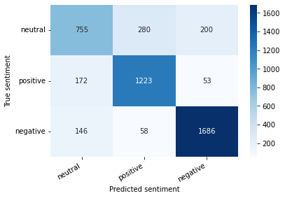

```python
def show_confusion_matrix(confusion_matrix):
    hmap = sns.heatmap(confusion_matrix, annot=True, fmt="d", cmap="Blues")
    hmap.yaxis.set_ticklabels(hmap.yaxis.get_ticklabels(), rotation=0, ha='right')
    hmap.xaxis.set_ticklabels(hmap.xaxis.get_ticklabels(), rotation=30, ha='right')
    plt.ylabel('True sentiment')
    plt.xlabel('Predicted sentiment');

cm = confusion_matrix(test_dataset['label'], test_pred)
df_cm = pd.DataFrame(cm, index=class_names, columns=class_names)
show_confusion_matrix(df_cm)
```

```python
# Сохраняем финальную модель
model.save_pretrained('./fine_tuned_model')
```

### 8. Классификация произвольного текста

```python
model = BertForSequenceClassification.from_pretrained('./fine_tuned_model')
model.to(device);
```

```python
# Соответствие числовых меток (индексов в данном списке) классам тональности:
# 'neutral': 0, 'positive': 1, 'negative': 2
class_names = ['neutral', 'positive', 'negative']
```

```python
text = 'Вы сегодня показали впечатляющие результаты'
#text = 'Настолько бесполезно было следовать вашим советам'
#text = 'Сегодня нужно зайти в магазин за фруктами'
```

```python
encoded_text = tokenizer(
    text,
    max_length=MAX_LEN,
    padding='max_length',
    truncation='longest_first',
    return_tensors='pt'
)
```

```python
input_ids = encoded_text['input_ids'].to(device)
attention_mask = encoded_text['attention_mask'].to(device)
output = model(input_ids, attention_mask)
_, prediction = torch.max(output['logits'], dim=1)
probs = softmax(output['logits'], dim=1)
print(f'Text: {text}')
print('\nSoftmax:', [f'{x:.4f}' for x in probs[0].tolist()])
print(f'\nSentiment: {class_names[prediction]}')
```

```
Text: Вы сегодня показали впечатляющие результаты

Softmax: ['0.0005', '0.9992', '0.0003']

Sentiment: positive
```